# Predicting *how (well)* an Weight Lifting Exercises was Performed

Julio Waissman Vilanova

February 23, 2017

## Problem description

In this work, a practical machine learning study was performed in order to predict the manner in which a individual perform a weight lifting exercise. Six young health participants were asked to perform one set of 10 repetitions of the Unilateral Dumbbell Biceps Curl in five different fashions: exactly according to the specification (Class A), throwing the elbows to the front (Class B), lifting the dumbbell only halfway (Class C), lowering the dumbbell only halfway (Class D) and throwing the hips to the front (Class E). Class A corresponds to the specified execution of the exercise, while the other 4 classes correspond to common mistakes.

Participants were supervised by an experienced weight lifter to make sure the execution complied to the manner they were supposed to simulate. The data was collected from accelerometers on the belt, forearm, arm, and dumbell.

More information on the data can be obtained from

> Velloso, E.; Bulling, A.; Gellersen, H.; Ugulino, W.; Fuks, H. “Qualitative Activity Recognition of Weight Lifting Exercises.” *Proceedings of 4th International Conference in Cooperation with SIGCHI (Augmented Human ’13).* Stuttgart, Germany: ACM SIGCHI, 2013.

The data is downloaded and read as

```r
if (!dir.exists("pml-data")){
    dir.create("pml-data")
    if (!file.exists("pml-data/pml-training.csv"))
        download.file("https://d396qusza40orc.cloudfront.net/predmachlearn/pml-training.csv",
                      "pml-data/pml-training.csv")
    if (!file.exists("pml-data/pml-testing.csv"))
        download.file("https://d396qusza40orc.cloudfront.net/predmachlearn/pml-testing.csv",
                      "pml-data/pml-testing.csv")
}

pml.train <- read.csv("pml-data/pml-training.csv",
                      na.strings = c('', 'NA', '"NA"', "#DIV/0"))
pml.test <- read.csv("pml-data/pml-testing.csv",
                     na.strings = c('', 'NA', '"NA"', "#DIV/0"))
```

## Preprocessing data

From a visual inspection of the data, there exists variables that have one unique value or they have very few unique values relative to the number of samples and the ratio of the frequency of the most common value to the frequency of the second most common value is large. Also, some variables have more than 50% of missing data. In these cases an imputation technique can not be applied. The data was cleaned as:

```r
library(caret)

# Near zero variables
nzv <- nearZeroVar(pml.train)
pml.train <- pml.train[, -nzv]
pml.test <- pml.test[, -nzv]

# Variables with more than 50% of missing values
a <- sapply(pml.train, function (l) sum(is.na(l))/19622 < 0.5)
pml.train <- pml.train[, a]
pml.test <- pml.test[, a]

# Checking if we keep some variables with missing values
# in order to use an imptation method
which(is.na(pml.train))
```

The objective of the project is to predict from data collected from accelerometers. If we used the time series information we could make a good prediction with the closest neighbor method, however that would be cheating. For this reason we remove all information related to the time series.

```r
pml.train0 <- pml.train[, -c(1,3,4,5)]
pml.test0 <- pml.test[, -c(1,3,4,5)]
```

While there are some learning methods that thrive on correlated predictors (such as pls), most of the methods may benefit from reducing the level of correlation between the predictors. We remove descriptors with absolute correlations above 0.9.

```r
des.cor <- cor(pml.train0[,2:54])
highly.cor <- findCorrelation(des.cor, cutoff = .9) + 1
pml.train0 <- pml.train0[, -highly.cor]
pml.test0 <- pml.test0[, -highly.cor]
```

At this point, it is important to perform a visual exploration of the data in order to explore which type of transformation and learnng algorithm can be useful. A PCA is performed in order to explore the 4 principal components.

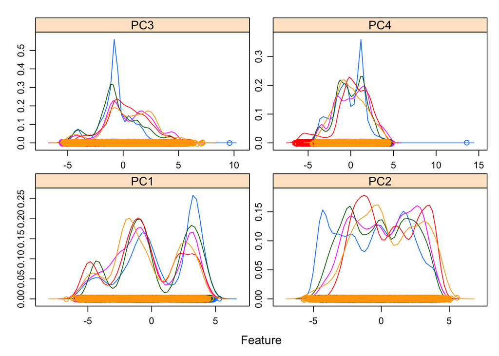

```r
trans <- preProcess(pml.train0, method='pca')
pml.train.pca <- predict(trans, pml.train0)

featurePlot(x = pml.train.pca[, 3:6],
            y = pml.train.pca$classe,
            plot = "density",
            scales = list(x = list(relation="free"),
                          y = list(relation="free")))
```

The figure illustrate that for the 4 first principal components, the distribution of the data is far to a normal distribution for each class, an even for the whole data. Thus, the PCA (and other data transformation based in the hypothesis that the data distribution is normal), can not be applied. Also, model based methods or generalized linear models can not be applied (due to the known probability distribution assumption). The only transformation methods to be applied to the numerical data is scaling and centering.

```r
cen.esc <- preProcess(pml.train0, method = c("center", "scale"))
pml.train1 <- predict(cen.esc, pml.train0)
pml.test1 <- predict(cen.esc, pml.test0)
```

## Prediction model

```r
set.seed(12345)
inTraining <- createDataPartition(pml.train1$classe,
                                  p = .75, list = FALSE)
training <- pml.train1[inTraining,]
validation <- pml.train1[-inTraining,]
```

In order to perform the prediction, we will use *K-folder-cross-validation*. Ideally, the best cross validation methos is *one-leave-out*, but that implies to perform 14717 trainig algorthms with 14717 objects each one. In order to perform the training phase in an acceptable time (using R in a old laptop) the 10-fold-cross-validation is performed without repetitions.

```r
fitControl <- trainControl(method = "cv", number = 10)
```

Two prediction models proposed in the course has the most effectives are performed and compared: Random Forest and Boosting:

```r
set.seed(54321)
mdl1 <- train(classe ~ ., data = training,
              method = "rf",
              trControl = fitControl,
              verbose = FALSE)

set.seed(54321)
mdl2 <- train(classe ~ ., data = training,
              method = "gbm",
              trControl = fitControl,
              verbose = FALSE)
```

## Models analysis

In order to compare the models, the `caret` package provides the function `resamples` in order to make statistical statements about their performance differences.

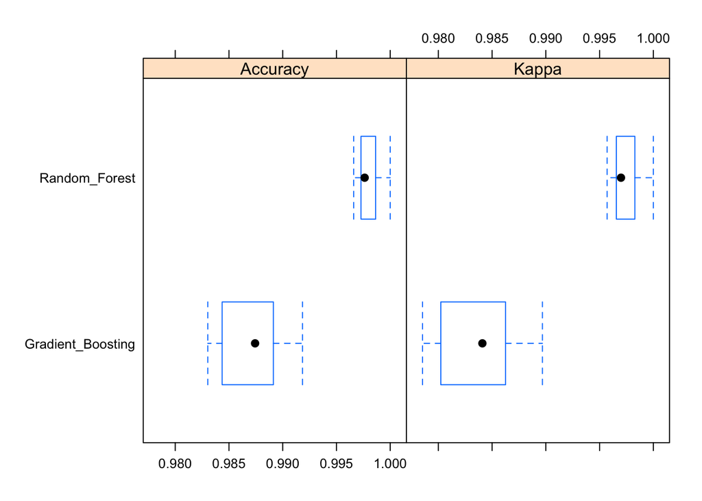

```r
resamps <- resamples(list(Random_Forest = mdl1,
                          Gradient_Boosting = mdl2))
bwplot(resamps, layout = c(2, 1))
```

From the figure we can highlight that both models have a very high accuracy (above 0.985 in average) but statistically the accuracy is better in the method of Random Forests.

In order to analyze the differences of the *in sample* errors versus an approximation of the *out sample* errors we will use the validation data and compare the results in a data frame.

```r
accuracy <- function (model, data)
    mean(data$classe == predict(model, data))
a <- data.frame(in.sample = c(accuracy(mdl1, training),
                              accuracy(mdl2, training)),
                out.sample = c(accuracy(mdl1, validation),
                               accuracy(mdl2, validation)),
                row.names = c('Random Forest', 'Gradient Boosting'))
knitr::kable(a)
```

|  | in.sample | out.sample |
| --- | --- | --- |
| Random Forest | 1.0000000 | 0.9965334 |
| Gradient Boosting | 0.9942248 | 0.9896003 |

From the table it can be seen that the difference in the accuracy obtained with the training data and the validation data is very small. For this reason, it can be expected that the prediction performed on data other than training data is very similar to that obtained with the training data, which is very good.

## Prediction

Finally, we will predict the classes of the test data with both models and we will compare the results.

```r
results <- data.frame(RF= predict(mdl1, pml.test1),
                      GBM = predict(mdl2, pml.test1))
knitr::kable(results)
```

| RF | GBM |
| --- | --- |
| B | B |
| A | A |
| B | B |
| A | A |
| A | A |
| E | E |
| D | D |
| B | B |
| A | A |
| A | A |
| B | B |
| C | C |
| B | B |
| A | A |
| E | E |
| E | E |
| A | A |
| B | B |
| B | B |
| B | B |

As we can see, both models coincide in all cases.

That’s all folks.